# Crime and Communities

Elias Junior Ghantous and Sebastian Bigelow-Mirmiran

December 14, 2019

```r
library(readr)
library(dplyr)
```

```r
library(ggplot2)
library(FactoMineR)
library(RColorBrewer)
library(caret)
library(pROC)
library(gbm)
library(class)
```

```r
CC <- read_csv("crime_and_communities_data.csv")
y <- CC$ViolentCrimesPerPop
X <- subset(CC, select = -c(ViolentCrimesPerPop))
# Summary of Predictor Variables
summary(X)
```

```
##    population      householdsize    racepctblack    racePctWhite
##  Min.   :  10005   Min.   :1.600   Min.   : 0.00   Min.   : 2.68
##  1st Qu.:  14359   1st Qu.:2.490   1st Qu.: 0.94   1st Qu.:75.88
##  Median :  22681   Median :2.650   Median : 3.15   Median :89.61
##  Mean   :  52251   Mean   :2.707   Mean   : 9.51   Mean   :83.49
##  3rd Qu.:  43154   3rd Qu.:2.850   3rd Qu.:11.96   3rd Qu.:95.99
##  Max.   :7322564   Max.   :5.280   Max.   :96.67   Max.   :99.63
##
##   racePctAsian      racePctHisp      agePct12t21     agePct12t29
##  Min.   : 0.0300   Min.   : 0.120   Min.   : 4.58   Min.   : 9.38
##  1st Qu.: 0.6125   1st Qu.: 0.920   1st Qu.:12.23   1st Qu.:24.38
##  Median : 1.2400   Median : 2.340   Median :13.62   Median :26.77
##  Mean   : 2.7508   Mean   : 8.482   Mean   :14.43   Mean   :27.62
##  3rd Qu.: 2.7375   3rd Qu.: 8.610   3rd Qu.:15.39   3rd Qu.:29.18
##  Max.   :57.4600   Max.   :95.290   Max.   :54.40   Max.   :70.51
##
##   agePct16t24      agePct65up       numbUrban          pctUrban
##  Min.   : 4.64   Min.   : 1.660   Min.   :      0   Min.   :  0.00
##  1st Qu.:11.34   1st Qu.: 8.922   1st Qu.:      0   1st Qu.:  0.00
##  Median :12.54   Median :11.855   Median :  17348   Median :100.00
##  Mean   :13.99   Mean   :12.005   Mean   :  46672   Mean   : 69.62
##  3rd Qu.:14.36   3rd Qu.:14.547   3rd Qu.:  41932   3rd Qu.:100.00
##  Max.   :63.62   Max.   :52.770   Max.   :7322564   Max.   :100.00
##
##    medIncome         pctWWage      pctWFarmSelf      pctWInvInc
##  Min.   : 11576   Min.   :31.68   Min.   :0.0000   Min.   : 7.91
##  1st Qu.: 23597   1st Qu.:73.22   1st Qu.:0.4700   1st Qu.:34.19
##  Median : 30896   Median :78.38   Median :0.7000   Median :42.38
##  Mean   : 33699   Mean   :78.08   Mean   :0.8933   Mean   :43.36
##  3rd Qu.: 41215   3rd Qu.:83.70   3rd Qu.:1.1100   3rd Qu.:52.07
##  Max.   :123625   Max.   :96.62   Max.   :6.5300   Max.   :89.04
##
##    pctWSocSec     pctWPubAsst       pctWRetire      medFamInc
##  Min.   : 4.81   Min.   : 0.500   Min.   : 3.46   Min.   : 13785
##  1st Qu.:20.98   1st Qu.: 3.362   1st Qu.:12.99   1st Qu.: 29307
##  Median :26.79   Median : 5.720   Median :15.66   Median : 36010
##  Mean   :26.66   Mean   : 6.806   Mean   :16.06   Mean   : 39553
##  3rd Qu.:31.84   3rd Qu.: 9.150   3rd Qu.:18.78   3rd Qu.: 46683
##  Max.   :76.39   Max.   :26.920   Max.   :45.51   Max.   :131315
##
```

[output cut: 193 more lines]

```
##  Min.   :   10   Min.   : 0.000   Min.   :  20.0   Min.   :2.380e+06
##  1st Qu.: 1171   1st Qu.: 0.350   1st Qu.:  54.0   1st Qu.:7.247e+06
##  Median : 1996   Median : 1.220   Median :  86.0   Median :1.075e+07
##  Mean   : 2790   Mean   : 3.063   Mean   : 177.3   Mean   :2.896e+07
##  3rd Qu.: 3270   3rd Qu.: 3.377   3rd Qu.: 191.0   3rd Qu.:2.047e+07
##  Max.   :44230   Max.   :54.330   Max.   :3187.0   Max.   :1.617e+09
##                                   NA's   :1675     NA's   :1675
##  LemasPctPolicOnPatr LemasGangUnitDeploy LemasPctOfficDrugUn PolicBudgPerPop
##  Min.   :10.85       Min.   : 0.000      Min.   : 0.00       Min.   :  15260
##  1st Qu.:83.87       1st Qu.: 0.000      1st Qu.: 0.00       1st Qu.:  86869
##  Median :89.44       Median : 5.000      Median : 0.00       Median : 114582
##  Mean   :86.77       Mean   : 4.404      Mean   : 1.01       Mean   : 154590
##  3rd Qu.:93.06       3rd Qu.:10.000      3rd Qu.: 0.00       3rd Qu.: 156961
##  Max.   :99.94       Max.   :10.000      Max.   :48.44       Max.   :2422367
##  NA's   :1675        NA's   :1675                            NA's   :1675
```

```r
# Summary Of Response Variable
summary(y)
```

```
##    Min. 1st Qu.  Median    Mean 3rd Qu.    Max.
##     0.0   161.7   374.1   589.1   794.4  4877.1
```

```r
set.seed(12345)
```

#### Removing NA Columns and Scaling Data

```r
X <- subset(X, select = -c(PolicCars, PolicOperBudg, LemasPctPolicOnPatr, LemasGangUnitDeploy, PolicBudgPerPop, LemasSwornFT, LemasSwFTPerPop, LemasSwFTFieldOps, LemasSwFTFieldPerPop, LemasTotalReq, LemasTotReqPerPop, PolicReqPerOffic, PolicPerPop, RacialMatchCommPol, PctPolicWhite, PctPolicBlack, PctPolicHisp, PctPolicAsian, PctPolicMinor, OfficAssgnDrugUnits, NumKindsDrugsSeiz, PolicAveOTWorked))

X <- scale(X, center = TRUE, scale = TRUE)
y <- scale(y, center = TRUE, scale = TRUE)
```

### Data Exploration

1. Which variables are categorical versus numerical? All of the variables are numerical.
2. What are the general summary statistics of the data? The summary statistics are listed above extensively.
3. How can these be visualized?

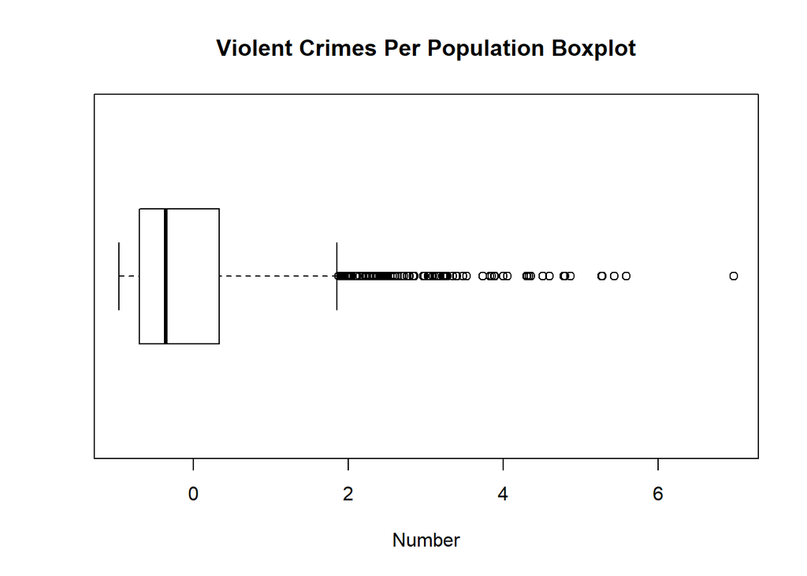

```r
boxplot(y, main = "Violent Crimes Per Population Boxplot", xlab = "Number", horizontal = TRUE)
```

The other summary statistics can be plotted similarly.

### Exploratory PCA

```r
PCA_results <- PCA(X, ncp = ncol(X))
```

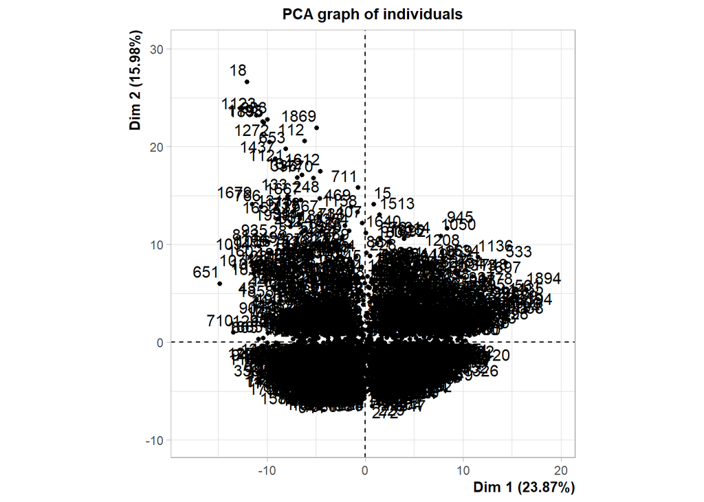

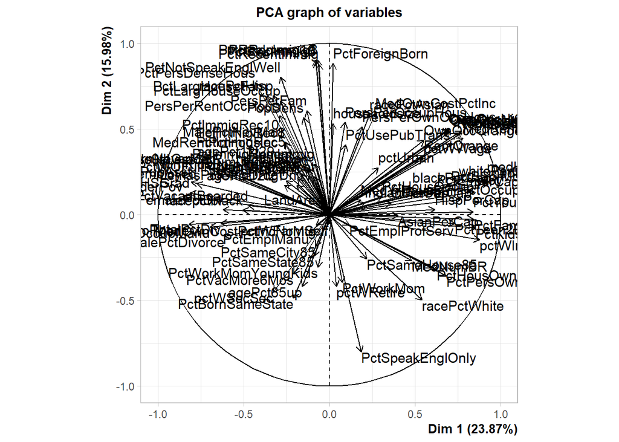

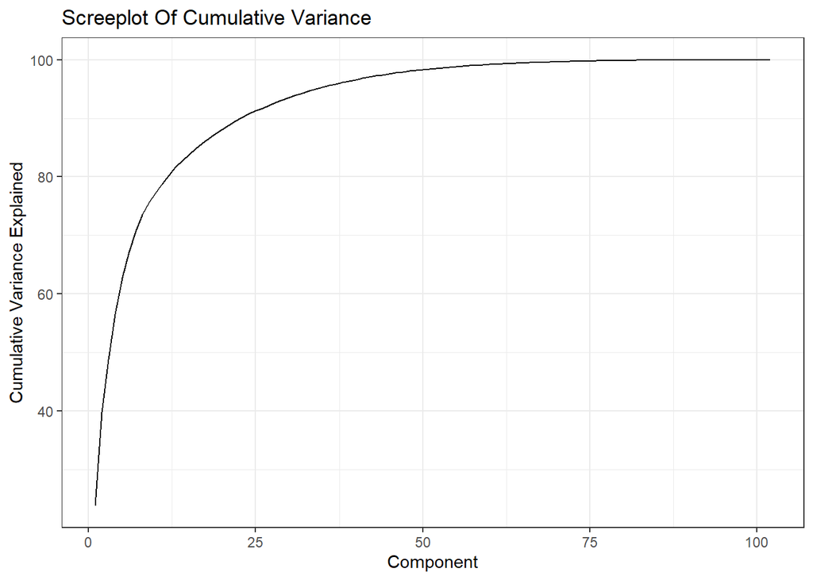

```r
screeplot_data <- as.data.frame(PCA_results$eig)
ggplot(data = screeplot_data, aes(x = 1:nrow(screeplot_data), y = screeplot_data[,3])) + geom_line() + theme_bw() + ylab("Cumulative Variance Explained") + xlab("Component") + ggtitle("Screeplot Of Cumulative Variance")
```

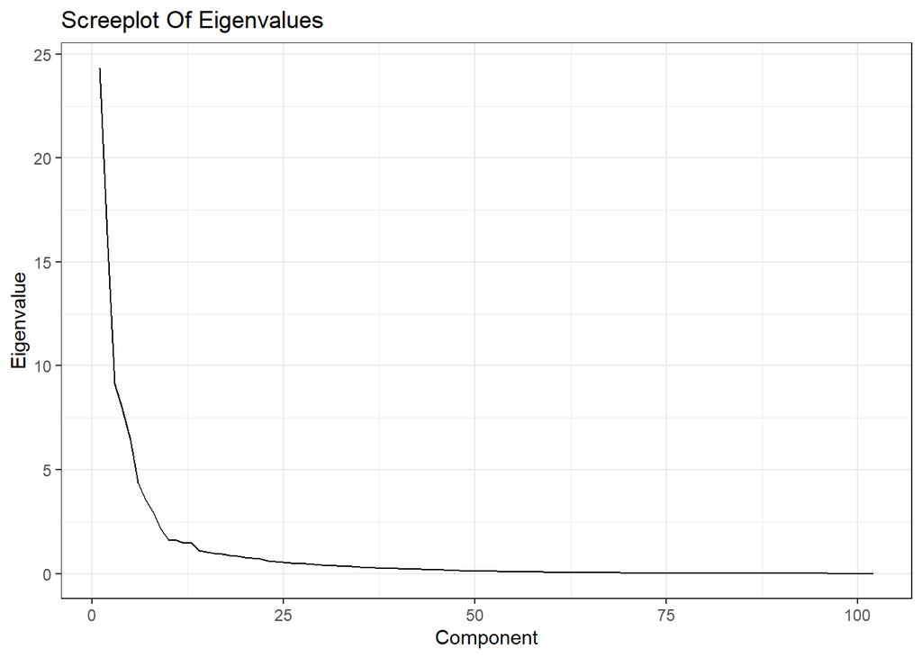

```r
ggplot(data = screeplot_data, aes(x = 1:nrow(screeplot_data), y = screeplot_data[,1])) + geom_line() + theme_bw() + ylab("Eigenvalue") + xlab("Component") + ggtitle("Screeplot Of Eigenvalues")
```

#### Making Sense of PCA (Transforming the Data)

```r
# transforming eigenvalues
loadings <- sweep(PCA_results$var$coord,2,sqrt(PCA_results$eig[1:ncol(PCA_results$var$coord),1]),FUN="/")

# making sense of the loadings
loadings <- abs(loadings)
loading_sums <- rowSums(loadings)
loadings_df <- cbind(loading_sums, c(1:length(loading_sums)))

# finding the most significant columns from PCA
loadings_df <- loadings_df[order(-loading_sums),]
colnames(loadings_df) <- c("loading sum", "columnnumber")
```

### Splitting and Preparing Data (Including PCA on Training Set)

```r
training_data_split <- sample.int(length(y)*0.8)
training_data_X <- X[training_data_split,]
training_data_y <- y[training_data_split]
testing_data_X <- X[-training_data_split,]
testing_data_y <- y[-training_data_split]

PCA_results <- PCA(training_data_X, ncp = ncol(X))
```

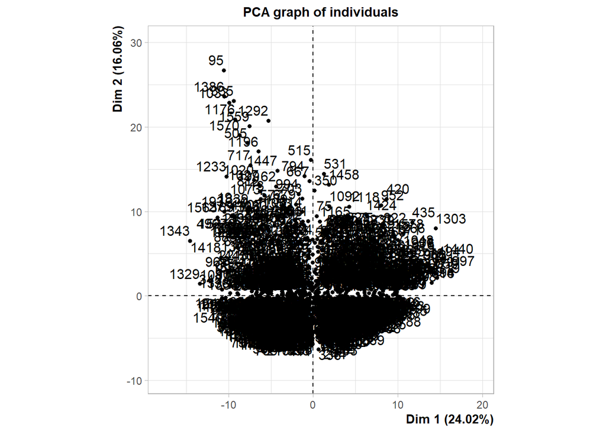

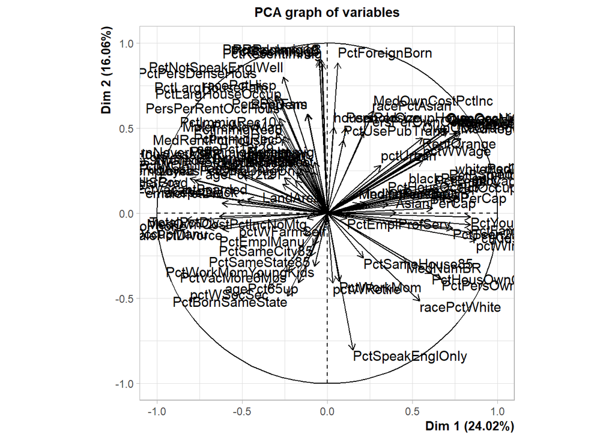

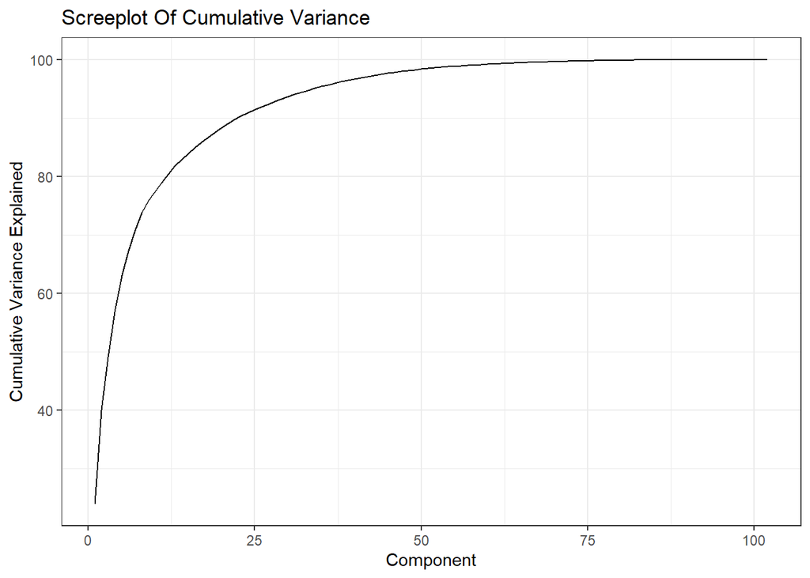

```r
screeplot_data <- as.data.frame(PCA_results$eig)
ggplot(data = screeplot_data, aes(x = 1:nrow(screeplot_data), y = screeplot_data[,3])) + geom_line() + theme_bw() + ylab("Cumulative Variance Explained") + xlab("Component") + ggtitle("Screeplot Of Cumulative Variance")
```

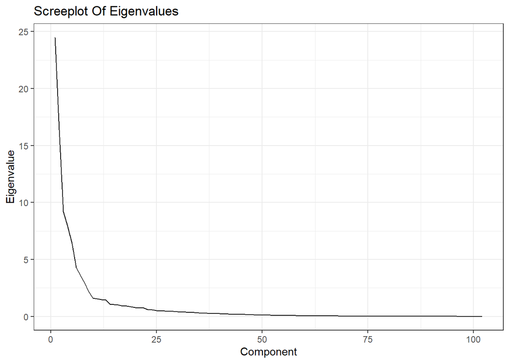

```r
ggplot(data = screeplot_data, aes(x = 1:nrow(screeplot_data), y = screeplot_data[,1])) + geom_line() + theme_bw() + ylab("Eigenvalue") + xlab("Component") + ggtitle("Screeplot Of Eigenvalues")
```

```r
loadings <- sweep(PCA_results$var$coord,2,sqrt(PCA_results$eig[1:ncol(PCA_results$var$coord),1]),FUN="/")

loadings <- abs(loadings)
loading_sums <- rowSums(loadings)
loadings_df <- cbind(loading_sums, c(1:length(loading_sums)))
loadings_df <- loadings_df[order(-loading_sums),]
colnames(loadings_df) <- c("loading sum", "columnnumber")

top_columns <- head(loadings_df[,2], 25)

training_data_X <- training_data_X[,sort(top_columns, decreasing = FALSE)]
testing_data_X <- testing_data_X[,sort(top_columns, decreasing = FALSE)]
training_data <- cbind.data.frame(training_data_X, training_data_y)
colnames(training_data)[ncol(training_data)] <- c("ViolentCrimesPerPop")
```

We chose the top 25 predictor variables after the PCA results in order to have the fewest number of variables that can explain around 90% of the variance of the data. This helps the models to come.

### Linear Regression Model With Cross-Validation

We use the cross validation to test the linear regression model without having to further reduce the training set into an additional holdout validation set and smaller training set. We have reduced the number of parameters that we regress on using PCA and look at the MSE across the different CV folds to analyze the performance of the model.

```r
i <- 1:nrow(training_data)
folds <- matrix(sample(i), nrow = 5, byrow = TRUE)
mserror_linear <- rep(0, nrow(folds))

for (i in 1:nrow(folds)){

  validation_set <- as.vector(folds[i,])
  validation_set_X <- training_data[validation_set, -ncol(training_data)]
  validation_set_y <- training_data[validation_set, ncol(training_data)]


  training_set <- as.vector(folds[-i,])
  training_set <- training_data[training_set,]

  model <- lm(ViolentCrimesPerPop ~ ., data = training_set)
  model.pred <- predict(model, as.data.frame(validation_set_X))

  mserror_linear[i] <- (sum((model.pred - validation_set_y)^2))/length(validation_set_y)

}

mserror_linear_best <- mean(mserror_linear)
mserror_linear_best
```

```
## [1] 0.391143
```

Averaging the MSE across the different folds we get an estimate of roughly .39 MSE, which we will be comparing to the alternative models.

In using K-Nearest Neighbors we have an additional hyperparameter of k that we need to select. Therefore, we run CV algorithm for each of the possible k’s within a reasonable range (between 1 and 100) and then look at the MSE for the different folds across these different k’s. Finally, we find the k that minimizes the MSE using CV and we use that MSE as our final accuracy score for the KNN model.

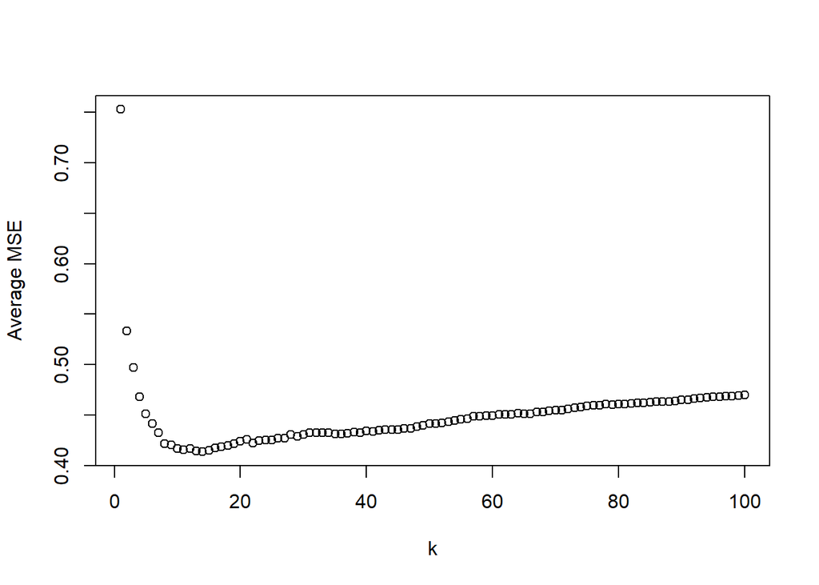

```r
k_values <- seq(from = 1, to = 100, by = 1)
mserror_kNN <- matrix(0, nrow = length(k_values), ncol = nrow(folds))

for (j in 1:length(k_values)){
  for (i in 1:nrow(folds)){

    validation_set <- as.vector(folds[i,])
    validation_set_X <- training_data[validation_set, -ncol(training_data)]
    validation_set_y <- training_data[validation_set, ncol(training_data)]


    training_set <- as.vector(folds[-i,])
    training_set_X <- training_data[training_set, -ncol(training_data)]
    training_set_y <- training_data[training_set, ncol(training_data)]

    fit <- knnreg(training_set_X, training_set_y, k = k_values[j])

    mserror_kNN[j,i] <- (sum((predict(fit, validation_set_X) - validation_set_y)^2))/length(validation_set_y)
  }
}

#finding best k
plot(x = k_values, y = (rowSums(mserror_kNN)/ncol(mserror_kNN)), ylab = "Average MSE", xlab = "k")
```

```r
best_k <- k_values[which.min(rowSums(mserror_kNN)/ncol(mserror_kNN))]
mserror_kNN_best <- min(rowSums(mserror_kNN)/ncol(mserror_kNN))
mserror_kNN_best
```

```
## [1] 0.4134921
```

Unforunately even with our best k we get an MSE of roughly .41 which is worse than our linear regression model.

### Penalized Regression Models With Cross-Validation

In an attempt to better our linear regression model we used penalized models, specifically lasso and ridge. We introduce here another hyperparameter, lambda, which we independently optimize for both models using CV.

```r
#Lasso Regression

lambda <- 10^seq(-3, 3, length = 100)

lasso <- train(
  ViolentCrimesPerPop ~., data = training_data, method = "glmnet",
  trControl = trainControl("cv", number = 10),
  tuneGrid = expand.grid(alpha = 1, lambda = lambda)
  )
# Model MSE
min((lasso$results$RMSE)^2)
```

```
## [1] 0.3831759
```

```r
# Ridge Regression

ridge <- train(
  ViolentCrimesPerPop ~., data = training_data, method = "glmnet",
  trControl = trainControl("cv", number = 10),
  tuneGrid = expand.grid(alpha = 0, lambda = lambda)
  )
# Model MSE
min((ridge$results$RMSE)^2)
```

```
## [1] 0.3824611
```

The ultimate result is that although both penalized models outperform the regular linear regression, the ridge regression marginally outperforms the lasso. We select this as our final model and it is trained on the entire training data set and ready for testing.

### Final Model Using Ridge Regression

Finally, we test the accuracy of our selected model, ridge regression, on the held out test data and find the MSE.

```r
testing_data <- cbind(testing_data_X, testing_data_y)
colnames(testing_data)[ncol(testing_data)] <- c("ViolentCrimesPerPop")

# Make predictions
predictions <- ridge %>% predict(testing_data)
# Model prediction performance
data.frame(
  RMSE = RMSE(predictions, testing_data[,ncol(testing_data)]),
  Rsquare = R2(predictions, testing_data[,ncol(testing_data)]),
  MSE = (RMSE(predictions, testing_data[,ncol(testing_data)]))^2
)
```

```
##        RMSE   Rsquare       MSE
## 1 0.6134068 0.5522283 0.3762679
```

Our final MSE is roughly .38, a good MSE but only a minor improvement over the other models we tested.